## Data Description

The data set provided for this study was sourced from IBM specifically from their Watson Analytics department. This is a ficitonal data set create by IBM data scientists to demonstrate the capabilities of their Watson analytics and predictive platform. For more details, refer to https://www.ibm.com/communities/analytics/watson-analytics-blog/hr-employee-attrition/.

The data set is provided in raw .csv format containing 15 continuous numeric, 6 categorical, 8 ordinal, and 6 binary variables.

### Continuous Numeric Variables:

| Variable Name | Description [Units] |
| --- | --- |
| Age: | Age of Employee |
| DailyRate: | Daily Pay Rate [US $ per Day] |
| DistanceFromHome: | Distance to Commute from Home to Work [Miles] |
| EmployeeNumber: | Employee Identification Number |
| HourlyRate: | Daily Pay Rate [US $ per Hour] |
| MonthlyIncome: | Monthly Income [US $] including benefits |
| MonthlyRate: | Monthly Pay Rate [US $ per Month] |
| NumCompaniesWorked: | Number of Companies that Employee has Worked at |
| PercentSalaryHike: | Percentage Increase in Salary [%] |
| TotalWorkingYears: | Total Work Experience [Number of Years] |
| TrainingTimesLastYear: | Number of Training Classes Attended Last Year |
| YearsAtCompany: | Years Spent by Employee Working at Current Company |
| YearsInCurrentRole: | Years Spent by Employee Working in Current Job Role |
| YearsSinceLastPromotion: | Years Since Employee Received Their Last Promotion |
| YearsWithCurrManager: | Years Spent by Employee Working with Current Manager |

### Categorical Variables:

| Variable Name | Description [Factor Levels] |
| --- | --- |
| BusinessTravel: | Amount of Business Travel [None / Rarely / Frequent] |
| Department: | Work Department [Sales / HR / R&D] |
| Education: | Education Level [Below College - Doctorate Degree] |
| EducationField: | Education Field / Major [Technical / Medical / Sciences etc.] |
| JobRole: | Job Role [Sales Exec / Lab Tech / Scientist / Manager etc.] |
| MaritalStatus: | Marital Status [Single / Married / Divorced] |

### Ordinal Variables:

[output not shown]

### Binary Variables:

| Variable Name | Description [Factor Levels] |
| --- | --- |
| Attrition: | Did the Employee Leave the Company? [Yes / No] |
| EmployeeCount | Count of the Employee of Interest [0 / 1] |
| Gender: | Gender of Employee [Male / Female] |
| Over18: | Is Employee over 18 Years Old [Yes / No] |
| OverTime: | Did the Employee Work OverTime [Yes / No] |
| StandardHours: | Standard Number of Working Hours per Pay Period [40 / 80] |

## Data Cleaning and Preparation

As with any data set, prior to diving into the analysis and model building, it is essential to check for any missing and erroneuous variables or even single values. After scanning through the provided .csv file and listing the variables in the previous data description section above, we decided to remove EmployeeNumber, EmployeeCount, Over18, and StandardHours are we felt that they did not provide any valuable information that can be used for the study. Surprisingly, We were not able to find any missing values and decided to proceed with the data set as is after removing the aformentioned variables.

## Data Exploration

Having looked through the raw .csv file to get a feel for the size and structure of the provided data set, it seemed that the next logical step was to visually explore how the attrition rate was affected by each variable.

To begin with, our team focused on the continuous numerical variables since they have a higher variance than categorical variables which in turn should result in a greater likelihood for significant differences in the attrition rate. Rather than looking through the 15 continuous variables one at a time, we created a correlation plot to provide as with a starting point. This plot also helped us find which variables are highly correlated suggesting that they are potentially explaining the same trend in attrition and will not be paired together when building our predictive model.

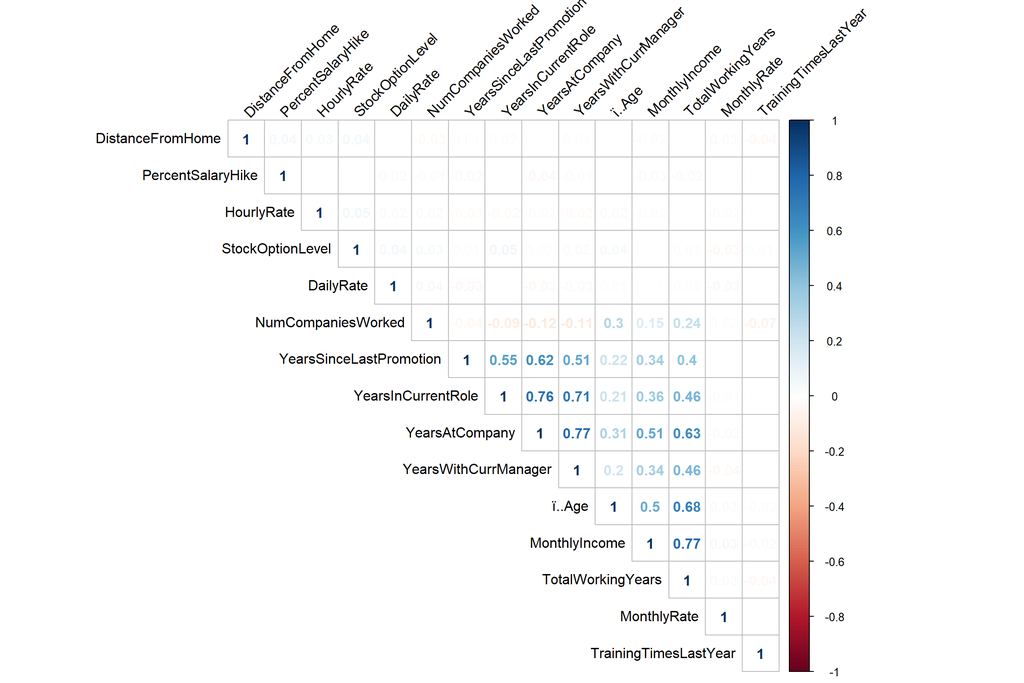

```r
# Use the select function from dplyr package to assign the 15 continuous numerical variables to a data frame object called Numeric_Vars
Numeric_Vars <- hr_employee_attrition %>%
  select(ï..Age, DailyRate, DistanceFromHome, HourlyRate, MonthlyIncome, MonthlyRate,
         NumCompaniesWorked, PercentSalaryHike, YearsAtCompany, YearsInCurrentRole,
         YearsSinceLastPromotion, YearsWithCurrManager, TotalWorkingYears,
         TrainingTimesLastYear, StockOptionLevel)

# Use corrplot function to create a correlation plot for the Numeric_Vars data frame
corrplot(cor(Numeric_Vars),
         method = "number",
         type = "upper",
         order = "hclust",
         tl.col = "black",
         tl.srt = 45)
```

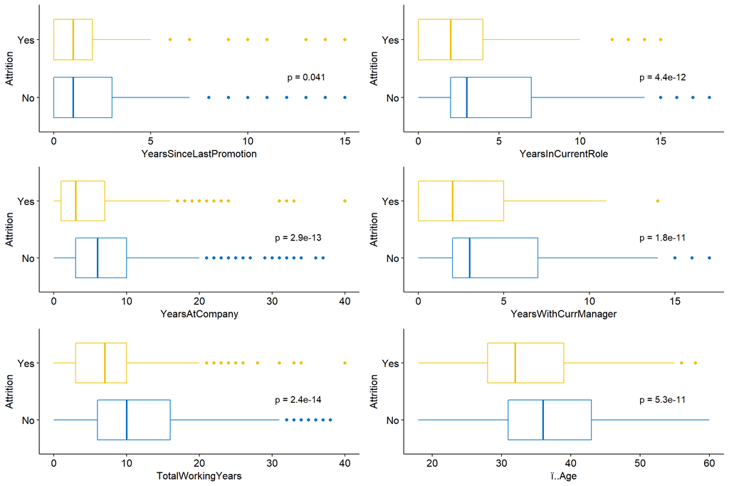

```r
# Change the ggplot2 theme to light for all plots going forward
theme_set(theme_light())

# Create horizontal side-by-side boxplot for Years Since Last Promotion Variable against attrition rate and store in object labelled Yrs_Since_Prom along with the p-value from the Wilcox non-parametric test for difference in two means
Yrs_Since_Prom <- ggboxplot(hr_employee_attrition,
                            x = "Attrition",
                            y = "YearsSinceLastPromotion",
                            color = "Attrition", palette = "jco") +
                            coord_flip() +
                            theme(legend.position = "none") +
                            stat_compare_means(method = "wilcox.test",
                                               label = "p.format",
                                               vjust = -2.5, hjust = 1.5)

# Create horizontal side-by-side boxplot for Years in Current Role Variable against attrition rate and store in object labelled Yrs_in_Role along with the p-value from the Wilcox non-parametric test for difference in two means
Yrs_In_Role <- ggboxplot(hr_employee_attrition,
                         x = "Attrition",
                         y = "YearsInCurrentRole",
                         color = "Attrition", palette = "jco") +
                         coord_flip() +
                         theme(legend.position = "none") +
                         stat_compare_means(method = "wilcox.test",
                                            label = "p.format",
                                            vjust = -2.5, hjust = 1.5)

# Create horizontal side-by-side boxplot for Years at Company Variable against attrition rate and store in object labelled Yrs_At_Comp along with the p-value from the Wilcox non-parametric test for difference in two means
Yrs_At_Comp <- ggboxplot(hr_employee_attrition,
                         x = "Attrition",
                         y = "YearsAtCompany",
                         color = "Attrition", palette = "jco") +
                         coord_flip() +
                         theme(legend.position = "none") +
                         stat_compare_means(method = "wilcox.test",
                                            label = "p.format",
                                            vjust = -2.5, hjust = 1.5)

# Create horizontal side-by-side boxplot for Years in Current with Current Manager against attrition rate and store in object labelled Yrs_With_Manager along with the p-value from the Wilcox non-parametric test for difference between two means
Yrs_With_Manager <- ggboxplot(hr_employee_attrition,
                              x = "Attrition",
                              y = "YearsWithCurrManager",
                              color = "Attrition", palette = "jco") +
                              coord_flip() +
                              theme(legend.position = "none") +
                              stat_compare_means(method = "wilcox.test",
                                                 label = "p.format",
                                                 vjust = -2.5, hjust = 1.5)

# Create horizontal side-by-side boxplot for Total Working Years Variable against attrition rate and store in object labelled Total_working_Years along with the p-value from the Wilcox non-parametric test for difference in two means
Total_working_Years <- ggboxplot(hr_employee_attrition,
                                 x = "Attrition",
                                 y = "TotalWorkingYears",
                                 color = "Attrition", palette = "jco") +
                                 coord_flip() +
                                 theme(legend.position = "none") +
                                 stat_compare_means(method = "wilcox.test",
                                                    label = "p.format",
                                                    vjust = -2.5, hjust = 1.5)

# Create horizontal side-by-side boxplot for Age Variable against attrition rate and store in object labelled Age along with the p-value from the Wilcox non-parametric test for difference in two means
Age <- ggboxplot(hr_employee_attrition,
                 x = "Attrition",
                 y = "ï..Age",
                 color = "Attrition", palette = "jco") +
                 coord_flip() +
                 theme(legend.position = "none") +
                 stat_compare_means(method = "wilcox.test",
                                    label = "p.format",
                                    vjust = -2.5, hjust = 1.5)

# Use grid.arrange function to display the plots created above in a 2 x 3 grid to save space but also for easier comparison
grid.arrange(Yrs_Since_Prom, Yrs_In_Role,
             Yrs_At_Comp, Yrs_With_Manager,
             Total_working_Years, Age,
             nrow = 3)
```

Our team didn’t want to stop there! We were curious to see what kind of trends we could identify amongst the other continuous variables. Our intuition told us that the employee pay rate should play a significant role in the attrition rate, however, the box plots in the grid below tell a somewhat different story.

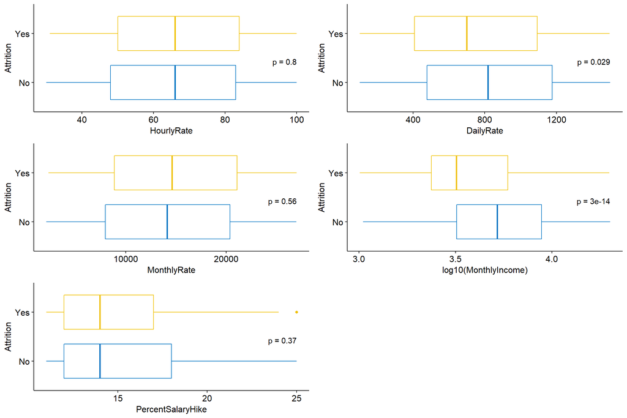

```r
# Create horizontal side-by-side boxplot for Hourly Pay Rate against attrition rate and store in object labelled Hourly_Rate along with the p-value from the Wilcox non-parametric test for difference in two means
Hourly_Rate <- ggboxplot(hr_employee_attrition,
                         x = "Attrition",
                         y = "HourlyRate",
                         color = "Attrition", palette = "jco") +
                         coord_flip() +
                         theme(legend.position = "none") +
                         stat_compare_means(method = "wilcox.test",
                                            label = "p.format",
                                            vjust = -3, hjust = 1)

# Create horizontal side-by-side boxplot for Daily Pay Rate against attrition rate and store in object labelled Daily_Rate along with the p-value from the Wilcox non-parametric test for difference in two means
Daily_Rate <- ggboxplot(hr_employee_attrition,
                        x = "Attrition",
                        y = "DailyRate",
                        color = "Attrition", palette = "jco") +
                        coord_flip() +
                        theme(legend.position = "none") +
                        stat_compare_means(method = "wilcox.test",
                                           label = "p.format",
                                           vjust = -3, hjust = 1)

# Create horizontal side-by-side boxplot for Monthly Pay Rate against attrition rate and store in object labelled Monthly_Rate along with the p-value from the Wilcox non-parametric test for difference in two means
Monthly_Rate <- ggboxplot(hr_employee_attrition,
                          x = "Attrition",
                          y = "MonthlyRate",
                          color = "Attrition", palette = "jco") +
                          coord_flip() +
                          theme(legend.position = "none") +
                          stat_compare_means(method = "wilcox.test",
                                             label = "p.format",
                                             vjust = -3, hjust = 1)

# Create horizontal side-by-side boxplot for Monthly Income against attrition rate and store in object labelled Monthly_Income along with the p-value from the Wilcox non-parametric test for difference in two means
Monthly_Income <- ggboxplot(hr_employee_attrition,
                            x = "Attrition",
                            y = "log10(MonthlyIncome)",
                            color = "Attrition", palette = "jco") +
                            coord_flip() +
                            theme(legend.position = "none") +
                            stat_compare_means(method = "wilcox.test",
                                               label = "p.format",
                                               vjust = -3, hjust = 1)

# Create horizontal side-by-side boxplot for Percentage Salary Hike variable against attrition rate and store in object labelled Perc_Salary_Hike along with the p-value from the Wilcox non-parametric test for difference in two means
Perc_Salary_Hike <- ggboxplot(hr_employee_attrition,
                              x = "Attrition",
                              y = "PercentSalaryHike",
                              color = "Attrition", palette = "jco") +
                              coord_flip() +
                              theme(legend.position = "none") +
                              stat_compare_means(method = "wilcox.test",
                                                 label = "p.format",
                                                 vjust = -3, hjust = 1)

# Use grid.arrange function to display the plots created above in a 3 row grid to save space but also for easier comparison
grid.arrange(Hourly_Rate, Daily_Rate,
             Monthly_Rate, Monthly_Income,
             Perc_Salary_Hike,
             nrow = 3)
```

The next variable of interest for our team was the daily work commute. No one likes spending a lot of their time everyday while driving to and from work. Instead of wasting time sitting in traffic and spending a lot of money of gas and vehicle maintenance, people would rather spend that time and energy at home with their friends and family.

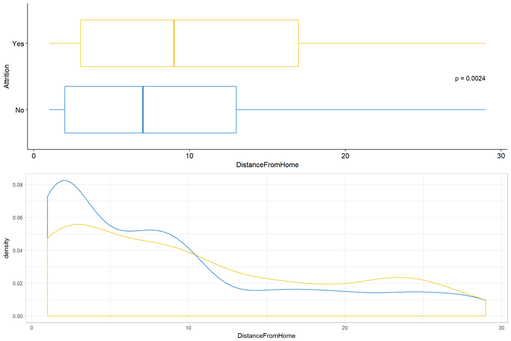

```r
# Create horizontal side-by-side boxplot for Distance From Home variable against attrition rate and store in object labelled Distance_Home_BoxPlot along with the p-value from the Wilcox non-parametric test for difference in two means
Distance_Home_BoxPlot <- ggboxplot(hr_employee_attrition,
                                   x = "Attrition",
                                   y = "DistanceFromHome",
                         color = "Attrition", palette = "jco") +
                         coord_flip() +
                         theme(legend.position = "none") +
                         stat_compare_means(method = "wilcox.test",
                                            label = "p.format",
                                            vjust = -6, hjust = 1)

# Create density plot for Distance From Home Variable
Distance_Home_DensityPlot <- ggplot(hr_employee_attrition,
                                    aes(x = DistanceFromHome,
                                        color = Attrition)) +
                                    geom_density() +
                                    scale_color_jco() +
                                    theme(legend.position = "none")

# Use grid.arrange function to display the plots created above in a 2 row grid to save space but also for easier comparison
grid.arrange(Distance_Home_BoxPlot,
             Distance_Home_DensityPlot,
             nrow = 2)
```

As expected, the boxplot shows that employees are more likely to leave if they have a greater distance to travel between home and work. Taking a closer look at the density plot, it seems that the attrition rate becomes a concern around the 10 mile mark.

Our next step was to look at the categorical variables in the data set. First on our list was to look at how the the gender and martial status of the employees affected the attrition rate. The grid below contains horizontal side-by-side boxplots for both variables to get a feel for the difference amongst the proportion of their factor levels.

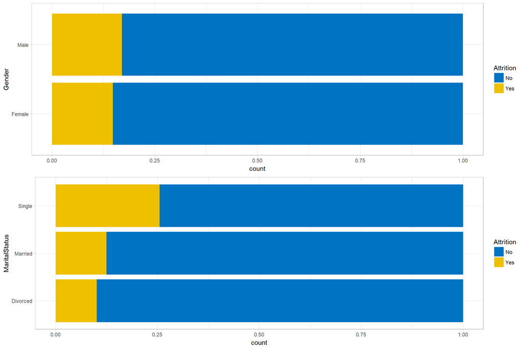

```r
# Use mutate function to refactor levels for Marital Status Variable to be able to create a side-by-side boxplot with correct labels
Marital_Status <- hr_employee_attrition %>%
  mutate(MaritalStatus = factor(MaritalStatus)) %>%
  mutate(MaritalStatus = fct_recode(MaritalStatus,
                                    "Single" = "Single",
                                    "Married" = "Married",
                                    "Divorced" = "Divorced"))

# Create horizontal side-by-side boxplot for Marital Status variable against attritionand store in object labelled Marital_Status_Plot
Marital_Status_Plot <- ggplot(Marital_Status,
                              aes(fill = Attrition, x = MaritalStatus)) +
                              geom_bar(position = 'fill') +
                              coord_flip() + scale_fill_jco()

# Use mutate function to refactor levels for Gender Variable to be able to create a side-by-side boxplot with correct labels
Gender <- hr_employee_attrition %>%
  mutate(Gender = factor(Gender)) %>%
  mutate(Gender = fct_recode(Gender,
                             "Male" = "Male",
                             "Female" = "Female"))

# Create horizontal side-by-side boxplot for Gender variable against attritionand store in object labelled Gender_Plot
Gender_Plot <- ggplot(Gender, aes(fill = Attrition, x = Gender)) +
                      geom_bar(position = 'fill') +
                      coord_flip() + scale_fill_jco()

# Use grid.arrange function to display the plots created above in a 2 row grid to save space but also for easier comparison
grid.arrange(Gender_Plot,
             Marital_Status_Plot,
             nrow = 2)
```

For the gender variable the attrition seems slightly higher for males than for females, however, the difference doesn’t look to be significant. On the other hand, the marital status told a different story. Single employees were more likely to leave the company when compared to ones that were married or divorced.

Our team then chose to look into categorical variables related to education and their department at work. Going down the boxplot grid below, we first see that employees with a background in higher education tend to have a smaller attrition rate when compared to those with little to no college education. People with a Bachelor degree still have a realtively high attrition rate and only once we get to the Master degree do we see a real step change. This could be due to people with higher levels of education being put in job roles with more responsibilities and higher pay rate thus having a greater incentive to stay at with the company. When looking a little closer at the education fields that people with higher degrees pursued, the ones with human resources, marketing and technical degrees had higher attrition rates that people with medical, life sciences, and other miscellaneous degrees. This could be due to the respective education fields with higher attrition having more job availability for the employees to pursue or that people in the medical and life science fields having a higher level of job satisfaction since they’re already working in their dreams jobs. The last chart somewhat echoes the second one described above with people in the sales and human resources departments having higher attrition rates than people in research and development.

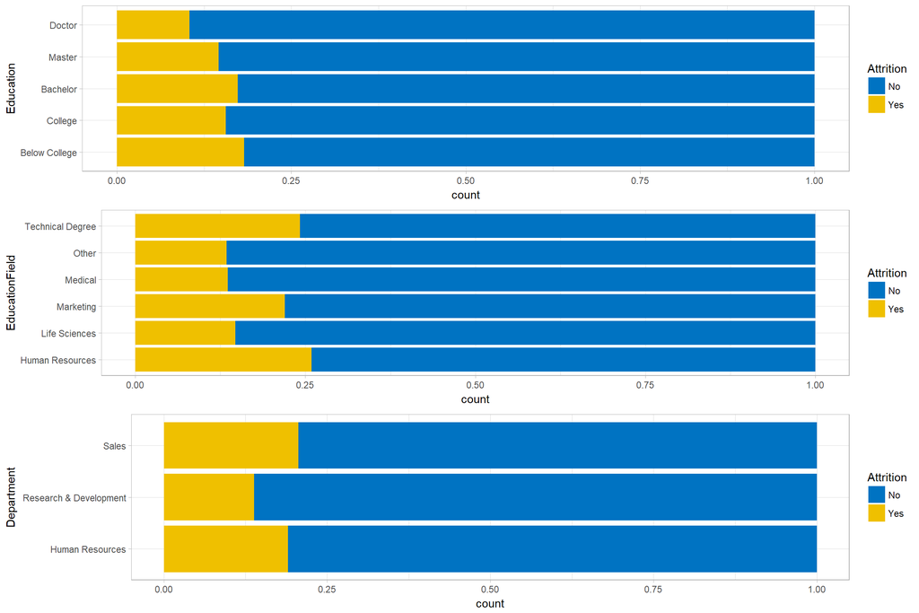

```r
# Use mutate function to refactor levels for Education Level variable to be able to create a side-by-side boxplot with correct labels
Education_Level <- hr_employee_attrition %>%
  mutate(Education = factor(Education)) %>%
  mutate(Education = fct_recode(Education,
                                "Below College" = "1",
                                "College" = "2",
                                "Bachelor" = "3",
                                "Master" = "4",
                                "Doctor" = "5"))

# Create horizontal side-by-side boxplot for Education Level variable against attritionand store in object labelled Education_Level_Plot
Education_Level_Plot <- ggplot(Education_Level,
                               aes(fill = Attrition, x = Education)) +
                               geom_bar(position = 'fill') +
                               coord_flip() + scale_fill_jco()

# Use mutate function to refactor levels for Education Field variable to be able to create a side-by-side boxplot with correct labels
Education_Field <- hr_employee_attrition %>%
  mutate(EducationField = factor(EducationField)) %>%
  mutate(EducationField = fct_recode(EducationField,
                                     "Technical Degree" = "Technical Degree",
                                     "Other" = "Other",
                                     "Medical" = "Medical",
                                     "Marketing" = "Marketing",
                                     "Life Sciences" = "Life Sciences",
                                     "Human Resources" = "Human Resources"))

# Create horizontal side-by-side boxplot for Education Field variable against attritionand store in object labelled Education_Field_Plot
Education_Field_Plot <- ggplot(Education_Field, aes(fill = Attrition, x = EducationField)) + geom_bar(position = 'fill') + coord_flip() + scale_fill_jco()

# Use mutate function to refactor levels for Department Variable to be able to create a side-by-side boxplot with correct labels
Department <- hr_employee_attrition %>%
  mutate(Department = factor(Department)) %>%
  mutate(Department = fct_recode(Department,
                                 "Sales" = "Sales",
                                 "Research & Development" = "Research & Development",
                                 "Human Resources" = "Human Resources"))

# Create horizontal side-by-side boxplot for Department variable against attritionand store in object labelled Department
Department_Plot <- ggplot(Department, aes(fill = Attrition, x = Department)) + geom_bar(position = 'fill') + coord_flip() + scale_fill_jco()

# Use grid.arrange function to display the plots created above in a 3 row grid to save space but also for easier comparison
grid.arrange(Education_Level_Plot,
             Education_Field_Plot,
             Department_Plot,
             nrow = 3)
```

Having looked through the effect of education, we thought that the variables related to job demands could have a signficant impact. Naturally, employees with low levels of job satisfaction have much higher levels of attrition but that only improves when the employees have very high job satisfaction. This same trend is reflected in the chart for work life balance where we see that the a bad balance has a very high attrition rate of ~ 30%. The last chart also follows the expected trend that jobs with demanding travel requirments tend to lose the more people than ones with little to no travel.

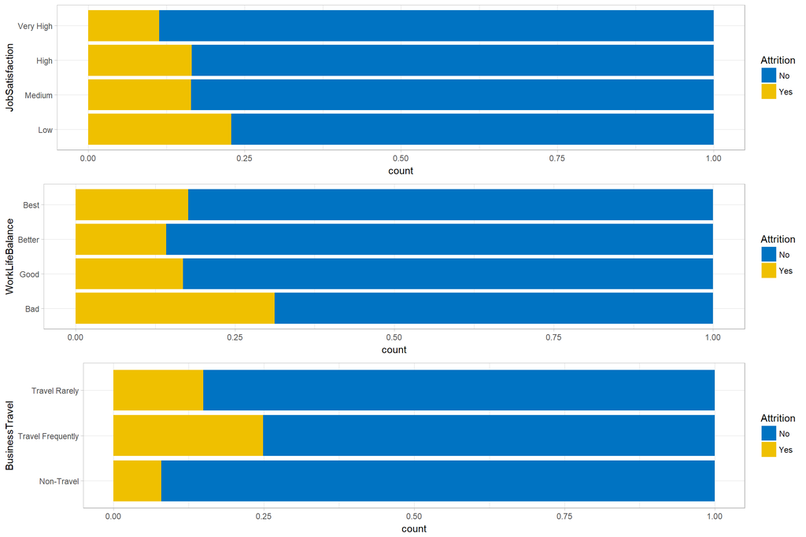

```r
# Use mutate function to refactor levels for Job Satisfaction to be able to create a side-by-side boxplot with correct labels
Job_Satisfaction_Level <- hr_employee_attrition %>%
  mutate(JobSatisfaction = factor(JobSatisfaction)) %>%
  mutate(JobSatisfaction = fct_recode(JobSatisfaction,
                                      "Low" = "1",
                                      "Medium" = "2",
                                      "High" = "3",
                                      "Very High" = "4"))

# Create horizontal side-by-side boxplot for Job Satisfaction variable against attritionand store in object labelled Job_Satisfaction_Level
Job_Satisfaction_Level_Plot <- ggplot(Job_Satisfaction_Level,
                                      aes(fill = Attrition, x = JobSatisfaction)) +
                                      geom_bar(position = 'fill') +
                                      coord_flip() + scale_fill_jco()

# Use mutate function to refactor levels for Work Life Balance Variable to be able to create a side-by-side boxplot with correct labels
Work_Life_Balance <- hr_employee_attrition %>%
  mutate(WorkLifeBalance = factor(WorkLifeBalance)) %>%
  mutate(WorkLifeBalance = fct_recode(WorkLifeBalance,
                                      "Bad" = "1",
                                      "Good" = "2",
                                      "Better" = "3",
                                      "Best" = "4"))

# Create horizontal side-by-side boxplot for Work Life Balance variable against attritionand store in object labelled Work_Life_Balance_Plot
Work_Life_Balance_Plot <- ggplot(Work_Life_Balance,
                                 aes(fill = Attrition, x = WorkLifeBalance)) +
                                 geom_bar(position = 'fill') +
                                 coord_flip() + scale_fill_jco()

# Use mutate function to refactor levels for Business Travel to be able to create a side-by-side boxplot with correct labels
Business_Travel <- hr_employee_attrition %>%
  mutate(BusinessTravel = factor(BusinessTravel)) %>%
  mutate(BusinessTravel = fct_recode(BusinessTravel,
                                     "Travel Frequently" = "Travel_Frequently",
                                     "Travel Rarely" = "Travel_Rarely",
                                     "Non-Travel" = "Non-Travel"))

# Create horizontal side-by-side boxplot for Business Travel variable against attritionand store in object labelled Business_Travel_Plot
Business_Travel_Plot <- ggplot(Business_Travel,
                              aes(fill = Attrition, x = BusinessTravel)) +
                              geom_bar(position = 'fill') +
                              coord_flip() + scale_fill_jco()

# Use grid.arrange function to display the plots created above in a 2 row grid to save space but also for easier comparison
grid.arrange(Job_Satisfaction_Level_Plot,
             Work_Life_Balance_Plot,
             Business_Travel_Plot,
             nrow = 3)
```

Moving down the list of categorical variables, we decided to look at the job involvement and performance rating of the employees. The first chart shows a clear downward trend in attrition as people become more involved in their jobs which seems intuitive since people that are not heavily involved are not very engaged in the company and are probably already thinking of their next move. The performance rating doesn’t seem to have any influence on the attrition rate with the caveat that all the employees were rated as either excellent or outstanding suggesting that all the employees are content with their rating and feel that it is well deserved or that employees with poor ratings had already left the company prior to the data collection phase for this study.

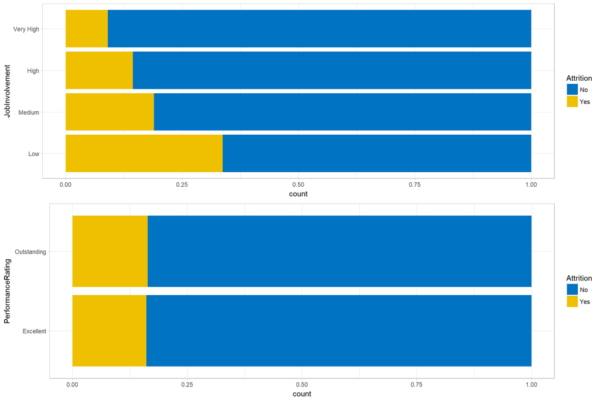

```r
# Use mutate function to refactor levels for Job Involvement Variable to be able to create a side-by-side boxplot with correct labels
Job_Involvement <- hr_employee_attrition %>%
  mutate(JobInvolvement = factor(JobInvolvement)) %>%
  mutate(JobInvolvement = fct_recode(JobInvolvement,
                                     "Low" = "1",
                                     "Medium" = "2",
                                     "High" = "3",
                                     "Very High" = "4"))

# Create horizontal side-by-side boxplot for Job Involvement variable against attritionand store in object labelled Job_Involvement_Plot
Job_Involvement_Plot <- ggplot(Job_Involvement,
                               aes(fill = Attrition, x = JobInvolvement)) +
                               geom_bar(position = 'fill') +
                               coord_flip() + scale_fill_jco()

# Use mutate function to refactor levels for Performance Rating Variable to be able to create a side-by-side boxplot with correct labels
Performance_Rating <- hr_employee_attrition %>%
  mutate(PerformanceRating = factor(PerformanceRating)) %>%
  mutate(PerformanceRating = fct_recode(PerformanceRating,
                                        "Low" = "1",
                                        "Good" = "2",
                                        "Excellent" = "3",
                                        "Outstanding" = "4"))
# Create horizontal side-by-side boxplot for Performance Rating variable against attritionand store in object labelled Performance_Rating_Plot
Performance_Rating_Plot <- ggplot(Performance_Rating,
                                  aes(fill = Attrition, x = PerformanceRating)) +
                                  geom_bar(position = 'fill') +
                                  coord_flip() + scale_fill_jco()

# Use grid.arrange function to display the plots created above in a 2 row grid to save space but also for easier comparison
grid.arrange(Job_Involvement_Plot,
             Performance_Rating_Plot,
             nrow = 2)
```

Our next set of variables were related to working conditions. For both the employee relationship status with their coworkers and their surrounding office environment, only the low levels seems to increase the attrition level. From the medium through to the very high levels, there didn’t seem to be any change in attrition.

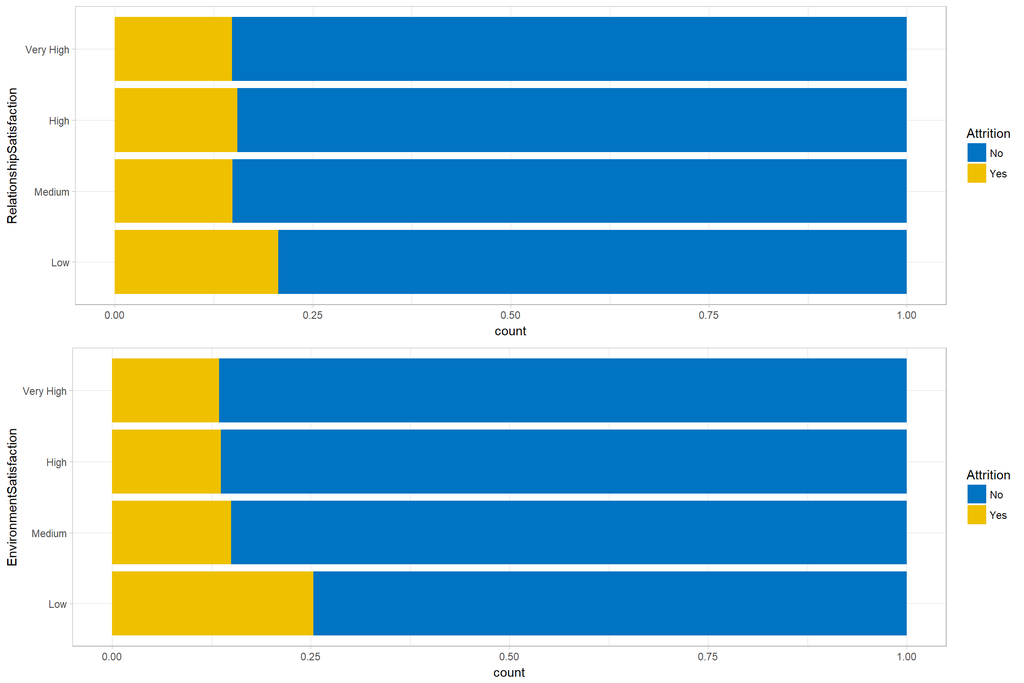

```r
# Use mutate function to refactor levels for Relationship Satisfaction variable to be able to create a side-by-side boxplot with correct labels
Relationship_Satisfaction <- hr_employee_attrition %>%
  mutate(RelationshipSatisfaction = factor(RelationshipSatisfaction)) %>%
  mutate(RelationshipSatisfaction = fct_recode(RelationshipSatisfaction,
                                               "Low" = "1",
                                               "Medium" = "2",
                                               "High" = "3",
                                               "Very High" = "4"))

# Create horizontal side-by-side boxplot for Relationship Satisfaction variable against attritionand store in object labelled Relationship_Satisfaction_Plot
Relationship_Satisfaction_Plot <- ggplot(Relationship_Satisfaction,
                                         aes(fill = Attrition, x = RelationshipSatisfaction)) +                                          geom_bar(position = 'fill') +
                                         coord_flip() + scale_fill_jco()

# Use mutate function to refactor levels for Environment Satisfcation variable to be able to create a side-by-side boxplot with correct labels
Environment_Satisfaction <- hr_employee_attrition %>%
  mutate(EnvironmentSatisfaction = factor(EnvironmentSatisfaction)) %>%
  mutate(EnvironmentSatisfaction = fct_recode(EnvironmentSatisfaction,
                                              "Low" = "1",
                                              "Medium" = "2",
                                              "High" = "3",
                                              "Very High" = "4"))

# Create horizontal side-by-side boxplot for Environment Satisfaction variable against attritionand store in object labelled Environment_Satisfcation_Plot
Environment_Satisfaction_Plot <- ggplot(Environment_Satisfaction,
                                        aes(fill = Attrition, x = EnvironmentSatisfaction)) +                                         geom_bar(position = 'fill') +
                                        coord_flip() + scale_fill_jco()

# Use grid.arrange function to display the plots created above in a 2 row grid to save space but also for easier comparison
grid.arrange(Relationship_Satisfaction_Plot,
             Environment_Satisfaction_Plot,
             nrow = 2)
```

For the last set of categorical variables, we grouped what we thought of as miscellaneous job benefits. The stock option level had an interesting trend with employees that hadn’t been granted any stock options showing almost 25% attrition which significantly dropped when employees had levels 1 and 2 but then jumped up again for employees in the level 3 category. We tought that the more stock options that employees had, the more likely they would be to stay with the company but upon closer inspection, we noticed that there was a small amount of employees in the highest level thus it would take much to influence the mean value of atrition. The number of times that an employee recived training during the previous year also had an interesting trend. As expected, when employees don’t receive any training at all, they are more likely to feel incompetent in their job role and therefore leave the company. This attrition rate significantly drops off once employees begin to get more training but the slightly increases when there went to 4 training classes and drops off again after that. This shows that there might be a sweet spot to the amount of training that employees prefer with the possibility of feeling like they are taking too many classes to where it almost become counterproductive.

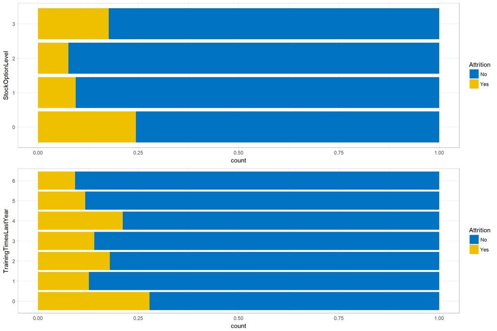

```r
# Use mutate function to refactor levels for Stock Option Level variable to be able to create a side-by-side boxplot with correct labels
Stock_Option_Level <- hr_employee_attrition %>%
  mutate(StockOptionLevel = factor(StockOptionLevel)) %>%
  mutate(StockOptionLevel = fct_recode(StockOptionLevel,
                                       "0" = "0",
                                       "1" = "1",
                                       "2" = "2",
                                       "3" = "3"))

# Create horizontal side-by-side boxplot for Stock Option Level variable against attritionand store in object labelled Stock_Option_Level_Plot
Stock_Option_Level_Plot <- ggplot(Stock_Option_Level,
                                  aes(fill = Attrition, x = StockOptionLevel)) +
                                  geom_bar(position = 'fill') +
                                  coord_flip() + scale_fill_jco()

# Use mutate function to refactor levels for Training Times Last Year variable to be able to create a side-by-side boxplot with correct labels
Training_Times_Last_Year <- hr_employee_attrition %>%
  mutate(TrainingTimesLastYear = factor(TrainingTimesLastYear)) %>%
  mutate(TrainingTimesLastYear = fct_recode(TrainingTimesLastYear,
                                            "0" = "0",
                                            "1" = "1",
                                            "2" = "2",
                                            "3" = "3",
                                            "4" = "4",
                                            "5" = "5",
                                            "6" = "6"))

# Create horizontal side-by-side boxplot for Training Times Last Year variable against attritionand store in object labelled Training_Times_Last_Year_Plot
Training_Times_Last_Year_Plot <- ggplot(Training_Times_Last_Year,
                                        aes(fill = Attrition, x = TrainingTimesLastYear)) +                                         geom_bar(position = 'fill') +
                                        coord_flip() + scale_fill_jco()

# Use grid.arrange function to display the plots created above in a 2 row grid to save space but also for easier comparison
grid.arrange(Stock_Option_Level_Plot,
             Training_Times_Last_Year_Plot,
             nrow = 2)
```

After looking through the complete list of relevant numerical and categorical variables and identifying ones with a significant impact on the attrition rate, we decided to employ a random forest model to pick our top 3 variables.